# Bethesda IV - Statystyki Opisowe

Piotr Wiśniewski, Gosia Struk-Panfil, Ewa Zalewska

23 Apr 2025, godz. 09:28

## Rozkład zmiennych: wieku, czasu obserwacji i wymiaru guzków:

```r
#testy shapiro-wilka
shapiro.test(bethIV_2_lata$wiek)
```

```
##
##  Shapiro-Wilk normality test
##
## data:  bethIV_2_lata$wiek
## W = 0.97742, p-value = 0.005087
```

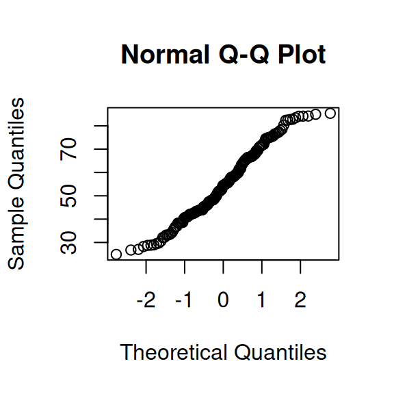

```r
qqnorm(bethIV_2_lata$wiek)
```

```r
shapiro.test(bethIV_2_lata$wiek[bethIV_2_lata$progresja_vol50 == 1])
```

```
##
##  Shapiro-Wilk normality test
##
## data:  bethIV_2_lata$wiek[bethIV_2_lata$progresja_vol50 == 1]
## W = 0.96894, p-value = 0.03128
```

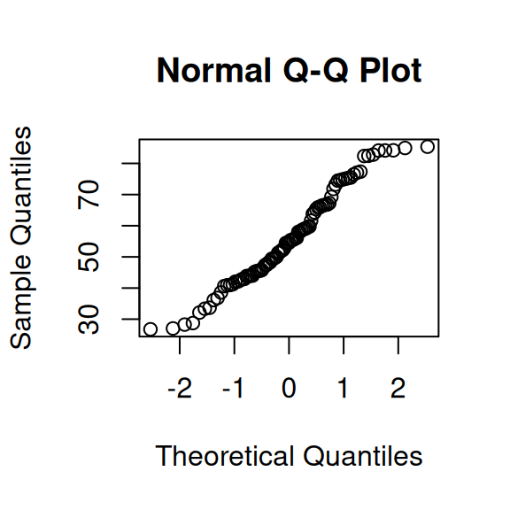

```r
qqnorm(bethIV_2_lata$wiek[bethIV_2_lata$progresja_vol50 == 1])
```

```r
shapiro.test(bethIV_2_lata$wiek[bethIV_2_lata$progresja_vol50 == 0])
```

```
##
##  Shapiro-Wilk normality test
##
## data:  bethIV_2_lata$wiek[bethIV_2_lata$progresja_vol50 == 0]
## W = 0.9767, p-value = 0.1019
```

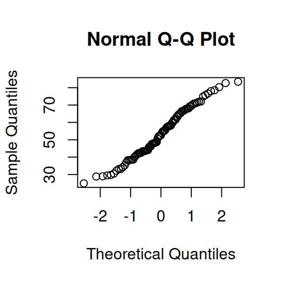

```r
qqnorm(bethIV_2_lata$wiek[bethIV_2_lata$progresja_vol50 == 0])
```

```r
shapiro.test(bethIV_2_lata$czas_nadzoru_lata)
```

```
##
##  Shapiro-Wilk normality test
##
## data:  bethIV_2_lata$czas_nadzoru_lata
## W = 0.78244, p-value = 4.432e-15
```

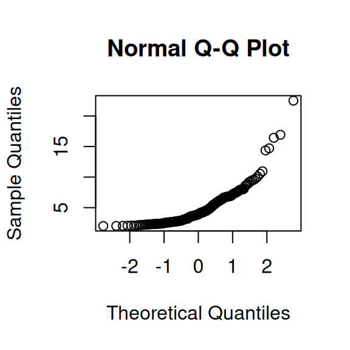

```r
qqnorm(bethIV_2_lata$czas_nadzoru_lata)
```

```r
shapiro.test(bethIV_2_lata$wymA)
```

```
##
##  Shapiro-Wilk normality test
##
## data:  bethIV_2_lata$wymA
## W = 0.85476, p-value = 4.252e-12
```

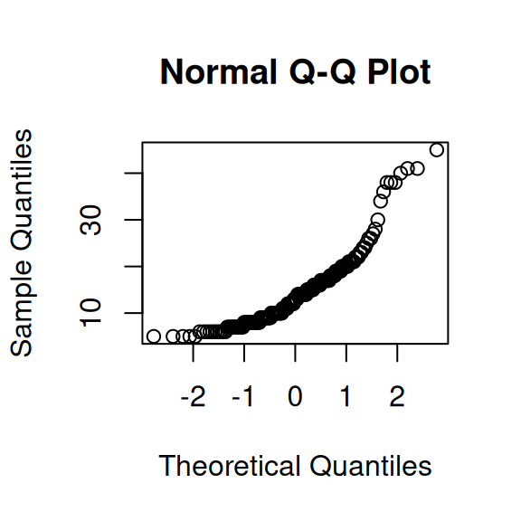

```r
qqnorm(bethIV_2_lata$wymA)
```

```r
shapiro.test(bethIV_2_lata$wymB)
```

```
##
##  Shapiro-Wilk normality test
##
## data:  bethIV_2_lata$wymB
## W = 0.84884, p-value = 2.238e-12
```

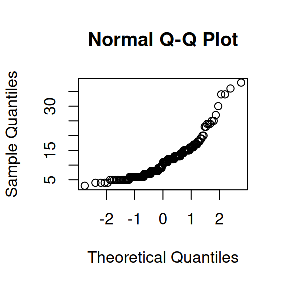

```r
qqnorm(bethIV_2_lata$wymB)
```

```r
shapiro.test(bethIV_2_lata$wymC)
```

```
##
##  Shapiro-Wilk normality test
##
## data:  bethIV_2_lata$wymC
## W = 0.86729, p-value = 1.756e-11
```

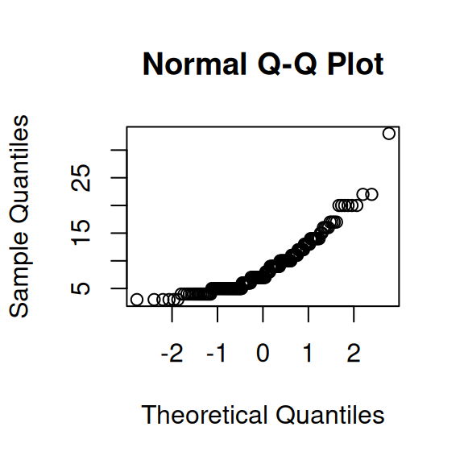

```r
qqnorm(bethIV_2_lata$wymC)
```

```r
shapiro.test(bethIV_2_lata$wymD)
```

```
##
##  Shapiro-Wilk normality test
##
## data:  bethIV_2_lata$wymD
## W = 0.90613, p-value = 2.756e-09
```

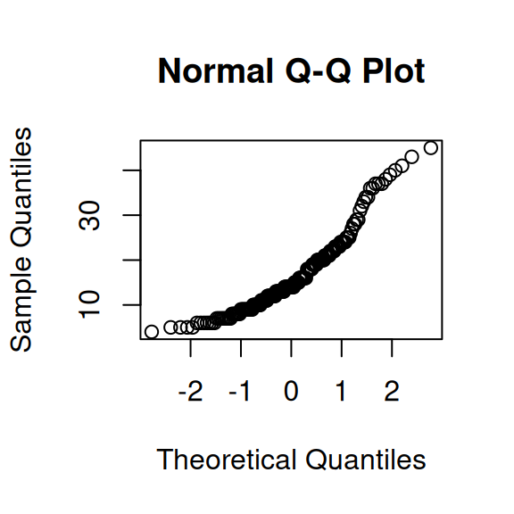

```r
qqnorm(bethIV_2_lata$wymD)
```

```r
shapiro.test(bethIV_2_lata$wymE)
```

```
##
##  Shapiro-Wilk normality test
##
## data:  bethIV_2_lata$wymE
## W = 0.8999, p-value = 1.129e-09
```

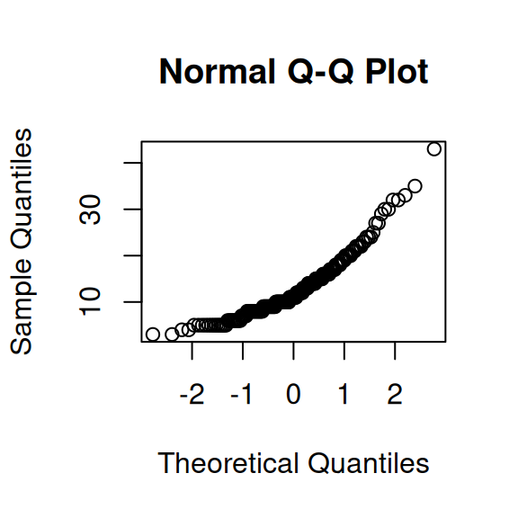

```r
qqnorm(bethIV_2_lata$wymE)
```

```r
shapiro.test(bethIV_2_lata$wymF)
```

```
##
##  Shapiro-Wilk normality test
##
## data:  bethIV_2_lata$wymF
## W = 0.89769, p-value = 8.305e-10
```

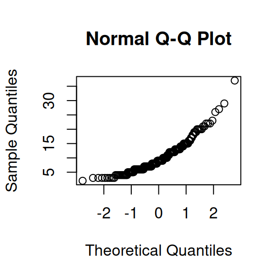

```r
qqnorm(bethIV_2_lata$wymF)
```

## Badanie ilosci osob z wynikiem jednoznacznym i niejednoznacznym:

```r
bethIV_2_lata %>%
  count(jednoznaczny_BAC)
```

```
## # A tibble: 2 × 2
##   jednoznaczny_BAC     n
##              <dbl> <int>
## 1                0    37
## 2                1   143
```

## Badanie ilosci kobiet i mężczyzn w grupie:

```r
bethIV_2_lata %>%
  group_by(sex) %>%
  count()
```

```
## # A tibble: 2 × 2
## # Groups:   sex [2]
##   sex       n
##   <chr> <int>
## 1 K       157
## 2 M        23
```

## Jaki procent stanowiły kobiet?

```r
bethIV_2_lata %>%
  summarise(procent_kobiet = 100 * mean(sex == "K", na.rm = TRUE))
```

```
## # A tibble: 1 × 1
##   procent_kobiet
##            <dbl>
## 1           87.2
```

## Jaka była średnia wieku?

```r
bethIV_2_lata %>%
  get_summary_stats(wiek, type = "common")
```

```
## # A tibble: 1 × 10
##   variable     n   min   max median   iqr  mean    sd    se    ci
##   <fct>    <dbl> <dbl> <dbl>  <dbl> <dbl> <dbl> <dbl> <dbl> <dbl>
## 1 wiek       180  24.9  85.4   54.5  23.1  54.8  15.0  1.12  2.20
```

## Jaki był średni czas nadzoru pacjentów?

```r
bethIV_2_lata %>%
  get_summary_stats(czas_nadzoru_lata, type = "common")
```

```
## # A tibble: 1 × 10
##   variable              n   min   max median   iqr  mean    sd    se    ci
##   <fct>             <dbl> <dbl> <dbl>  <dbl> <dbl> <dbl> <dbl> <dbl> <dbl>
## 1 czas_nadzoru_lata   180     2  22.5   3.92  3.58  4.87  2.99 0.223  0.44
```

## Jaki był największy guzek na początku obserwacji?

```r
bethIV_2_lata %>%
  get_summary_stats(wymA, type = "common")
```

```
## # A tibble: 1 × 10
##   variable     n   min   max median   iqr  mean    sd    se    ci
##   <fct>    <dbl> <dbl> <dbl>  <dbl> <dbl> <dbl> <dbl> <dbl> <dbl>
## 1 wymA       180     5    45     13  8.25  14.4  7.86 0.586  1.16
```

## Jaki był największy guzek na koniec obserwacji?

```r
bethIV_2_lata %>%
  get_summary_stats(wymD, type = "common")
```

```
## # A tibble: 1 × 10
##   variable     n   min   max median   iqr  mean    sd    se    ci
##   <fct>    <dbl> <dbl> <dbl>  <dbl> <dbl> <dbl> <dbl> <dbl> <dbl>
## 1 wymD       180     4    45     14    11  16.5  8.67 0.646  1.28
```

## Jaki był najmniejszy guzek początku obserwacji?

```r
bethIV_2_lata %>%
  get_summary_stats(wymC, type = "common")
```

```
## # A tibble: 1 × 10
##   variable     n   min   max median   iqr  mean    sd    se    ci
##   <fct>    <dbl> <dbl> <dbl>  <dbl> <dbl> <dbl> <dbl> <dbl> <dbl>
## 1 wymC       180     3    33      7     6  8.73  4.71 0.351 0.693
```

## Jaki był najmniejszy guzek na koniec obserwacji?

```r
bethIV_2_lata %>%
  get_summary_stats(wymF, type = "common")
```

```
## # A tibble: 1 × 10
##   variable     n   min   max median   iqr  mean    sd    se    ci
##   <fct>    <dbl> <dbl> <dbl>  <dbl> <dbl> <dbl> <dbl> <dbl> <dbl>
## 1 wymF       180     2    37      9     7  10.1  5.69 0.424 0.836
```

## Jaka była mediana wielkości biorąc pod uwagę wszystkie guzki (na początku i końcu obserwacji)?

```r
median(unlist(bethIV_2_lata[, c("wymA", "wymB", "wymC", "wymD", "wymE", "wymF")]), na.rm = TRUE)
```

```
## [1] 11
```

## Jaka była mediana wielkości guzków na początku obserwacji?

```r
median(unlist(bethIV_2_lata[, c("wymA", "wymB", "wymC")]), na.rm = TRUE)
```

```
## [1] 10
```

## Jaka była mediana wielkości guzków na końcu obserwacji?

```r
median(unlist(bethIV_2_lata[, c("wymD", "wymE", "wymF")]), na.rm = TRUE)
```

```
## [1] 12
```

## Koniec obserwacji – daty min. i max.

```r
summary(bethIV_2_lata$data_koncowa)
```

```
##         Min.      1st Qu.       Median         Mean      3rd Qu.         Max.
## "2010-07-15" "2023-01-28" "2023-11-25" "2023-05-21" "2024-02-24" "2025-05-09"
```

## Ile osób miało AITD?

```r
bethIV_2_lata %>%
  group_by(AITD) %>%
  count()
```

```
## # A tibble: 2 × 2
## # Groups:   AITD [2]
##    AITD     n
##   <dbl> <int>
## 1     0   143
## 2     1    37
```

## Jaki procent stanowiły osoby z AITD?

```r
bethIV_2_lata %>%
  summarise(procent_AITD = 100 * mean(AITD == 1, na.rm = TRUE))
```

```
## # A tibble: 1 × 1
##   procent_AITD
##          <dbl>
## 1         20.6
```

## Ile osób miało guzki oksyfilne?

```r
bethIV_2_lata %>%
  group_by(onkocytarna) %>%
  count()
```

```
## # A tibble: 2 × 2
## # Groups:   onkocytarna [2]
##   onkocytarna     n
##         <dbl> <int>
## 1           0   137
## 2           1    43
```

## Jaki procent stanowiły osoby ze zmianami onkocytarnymi?

```r
bethIV_2_lata %>%
  summarise(procent_onkocytarna = 100 * mean(onkocytarna == 1, na.rm = TRUE))
```

```
## # A tibble: 1 × 1
##   procent_onkocytarna
##                 <dbl>
## 1                23.9
```

## Ile osób miało progresję wielkości?

```r
bethIV_2_lata %>%
  group_by(progresja_vol50) %>%
  count()
```

```
## # A tibble: 2 × 2
## # Groups:   progresja_vol50 [2]
##   progresja_vol50     n
##             <int> <int>
## 1               0    91
## 2               1    89
```

## Jaki procent stanowiły osoby z progresją (biorąc pod uwagę objętość > 50%)?

```r
bethIV_2_lata %>%
  summarise(progresja_vol50 = 100 * mean(progresja_vol50 == 1, na.rm = TRUE))
```

```
## # A tibble: 1 × 1
##   progresja_vol50
##             <dbl>
## 1            49.4
```

## Ile osób zostało zoperowanych?

```r
bethIV_2_lata %>%
  group_by(operowany) %>%
  count()
```

```
## # A tibble: 2 × 2
## # Groups:   operowany [2]
##   operowany     n
##       <dbl> <int>
## 1         0   145
## 2         1    35
```

## Ile procent osób został zoperowanych?

```r
bethIV_2_lata %>%
  summarise(procent_operowany = 100 * mean(operowany == 1, na.rm = TRUE))
```

```
## # A tibble: 1 × 1
##   procent_operowany
##               <dbl>
## 1              19.4
```

## Ile osób z/bez progresji zostało zoperowanych?

```r
bethIV_2_lata %>%
  group_by(progresja_vol50, operowany) %>%
  count() %>%
  pivot_wider(
    names_from = "operowany",
    values_from = "n",
    names_prefix =  "operowany="
  )
```

```
## # A tibble: 2 × 3
## # Groups:   progresja_vol50 [2]
##   progresja_vol50 `operowany=0` `operowany=1`
##             <int>         <int>         <int>
## 1               0            77            14
## 2               1            68            21
```

## Jakie były rozp. hist-pat wśród osób z/bez progresji

```r
bethIV_2_lata %>%
  filter(operowany==1) %>%
  group_by(progresja_vol50) %>%
  count(hist_pat) %>%
  pivot_wider(
    names_from = "progresja_vol50",
    values_from = "n",
    names_prefix = "progresja_vol50 = ",
  )
```

```
## # A tibble: 7 × 3
##   hist_pat               `progresja_vol50 = 0` `progresja_vol50 = 1`
##   <chr>                                  <int>                 <int>
## 1 FTC                                        1                     5
## 2 FTUMP                                      1                     2
## 3 NIFTP                                      1                     2
## 4 gruczolak                                  5                     8
## 5 zmiana łagodna                             1                     1
## 6 zmiany hiperplastyczne                     4                     2
## 7 <NA>                                       1                     1
```

## Wykres indywidualnych zmian objętości guzków

```r
wykr_zm_obj_dane_long <- bethIV_2_lata %>%
  select(pacjent_id, obj_1, obj_2) %>%
  pivot_longer(
    cols = starts_with("obj_"),
    names_to = "pomiar",
    values_to = "objetosc"
  ) %>%
  mutate(
    pomiar = factor(pomiar,
     levels = c("obj_1", "obj_2"),
     labels = c("początek", "koniec"))
    ) %>%
  mutate(
    kierunek = if_else(objetosc[pomiar == "koniec"] >
                             objetosc[pomiar == "początek"],
                             "wzrost", "spadek"),
    .by = pacjent_id)
```

### Skala y natywna

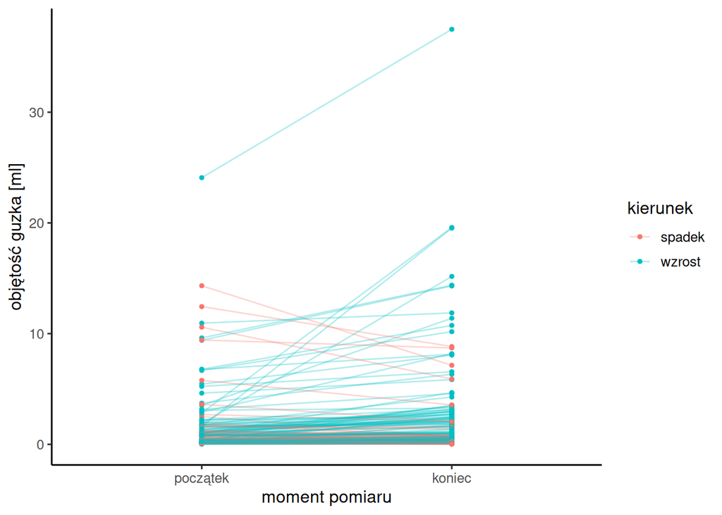

```r
wykr_zm_obj <- ggplot(wykr_zm_obj_dane_long, aes(x = pomiar, y = objetosc, color = kierunek, group = pacjent_id)) +
  geom_line(alpha = 0.3) +
  geom_point(size = 1) +
  labs(
    x = "moment pomiaru",
    y = "objętość guzka [ml]"
  ) +
  theme_classic2()

wykr_zm_obj
```

### Skala y logarytmiczna

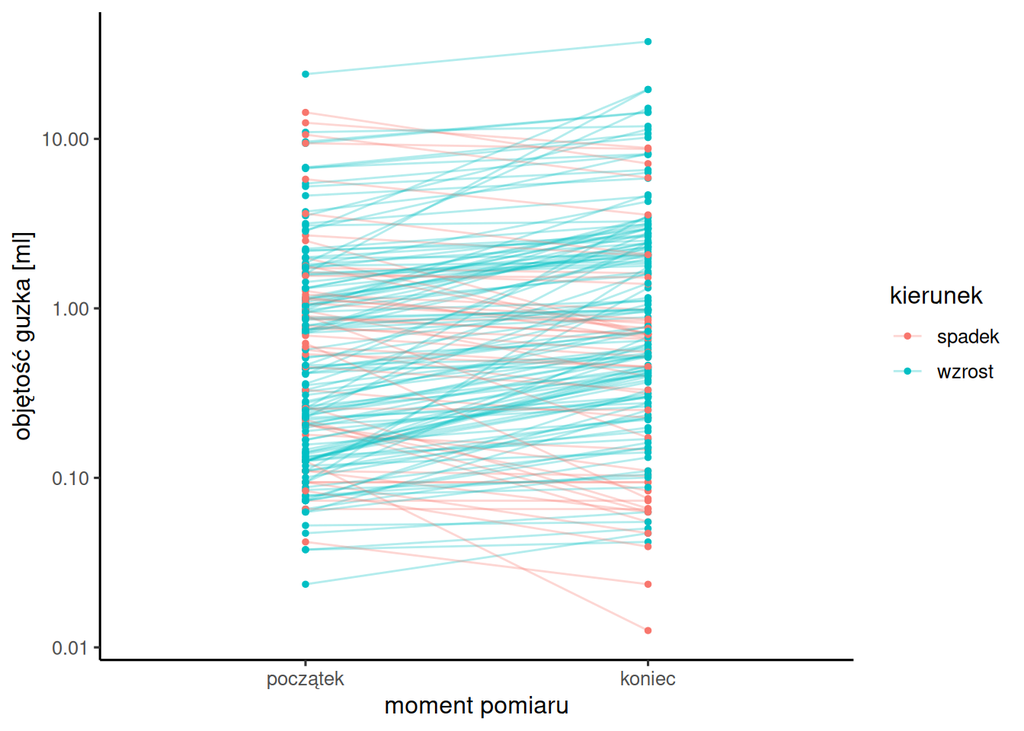

```r
wykr_zm_obj + scale_y_log10()
```

## Podsumowanie indywidualnych zmian objętości

```r
wykr_zm_obj_podsumowanie_dane <- wykr_zm_obj_dane_long |>
  distinct(pacjent_id, kierunek) |>
  count(kierunek) |>
  mutate(prop = n / sum(n),
         label = sprintf("%d (%.0f%%)", n, prop * 100))
```

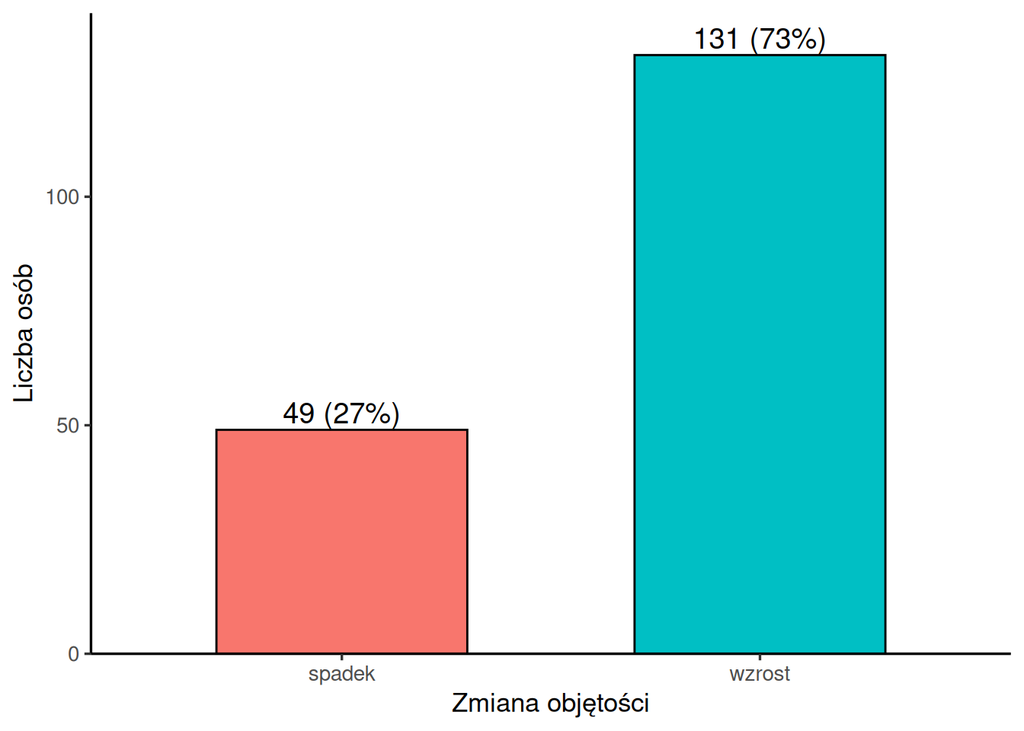

```r
ggplot(wykr_zm_obj_podsumowanie_dane,
       aes(x = kierunek,
           y = n,
           fill = kierunek)) +
  geom_col(width = 0.6, color = "black") +
  geom_text(aes(label = label), vjust = -0.3, size = 5) +
  scale_y_continuous(expand = expansion(mult = c(0, .07))) +
  labs(x = "Zmiana objętości",
       y = "Liczba osób" ) +
  theme(legend.position = "none")
```

## Ocena przyrostów objętości (tylko osoby z wzrostem objętości)

```r
wykr_zm_obj_wzrosty_dane <- bethIV_2_lata %>%
  select(pacjent_id, starts_with("obj_")) %>%
  filter(obj_delta_ml > 0)
```

```r
wykr_zm_obj_wzrosty_dane %>% get_summary_stats(-pacjent_id, type="full")
```

```
## # A tibble: 5 × 13
##   variable           n   min    max median     q1      q3     iqr    mad    mean
##   <fct>          <dbl> <dbl>  <dbl>  <dbl>  <dbl>   <dbl>   <dbl>  <dbl>   <dbl>
## 1 obj_1            131 0.024 2.41e1  0.415  0.136   1.31    1.18   0.498   1.35
## 2 obj_2            131 0.042 3.75e1  0.968  0.386   2.67    2.28   1.20    2.66
## 3 obj_delta_ml     131 0.003 1.79e1  0.314  0.141   1.30    1.16   0.38    1.31
## 4 obj_delta_pct    131 0.941 1.77e3 80     33.3   164.    131.    83.4   167.
## 5 obj_log_fold_…   131 0.009 2.93e0  0.588  0.288   0.971   0.684  0.51    0.751
## # ℹ 3 more variables: sd <dbl>, se <dbl>, ci <dbl>
```

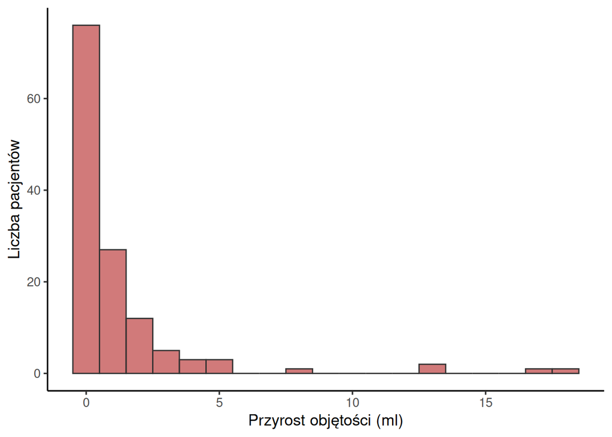

```r
ggplot(wykr_zm_obj_wzrosty_dane, aes(x=obj_delta_ml)) +
  geom_histogram(binwidth = 1, fill = "firebrick", colour = "grey20", alpha = .6) +
  labs(x = "Przyrost objętości (ml)",
       y = "Liczba pacjentów")
```

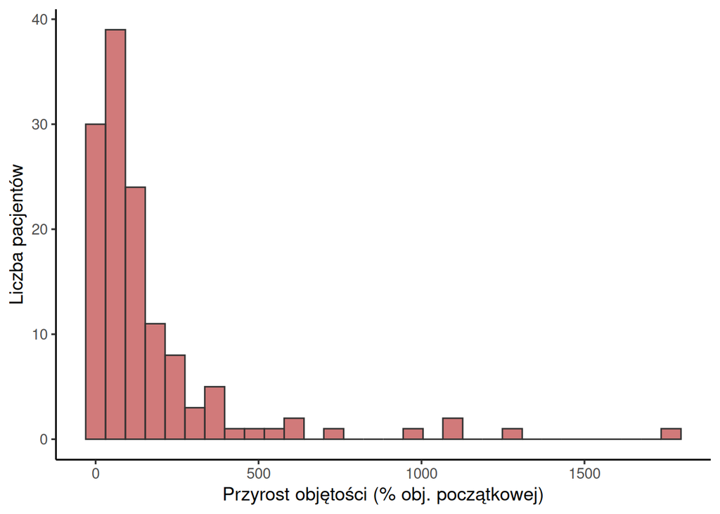

```r
ggplot(wykr_zm_obj_wzrosty_dane, aes(x=obj_delta_pct)) +
  geom_histogram( fill = "firebrick", colour = "grey20", alpha = .6) +
  labs(x = "Przyrost objętości (% obj. początkowej)",
       y = "Liczba pacjentów")
```

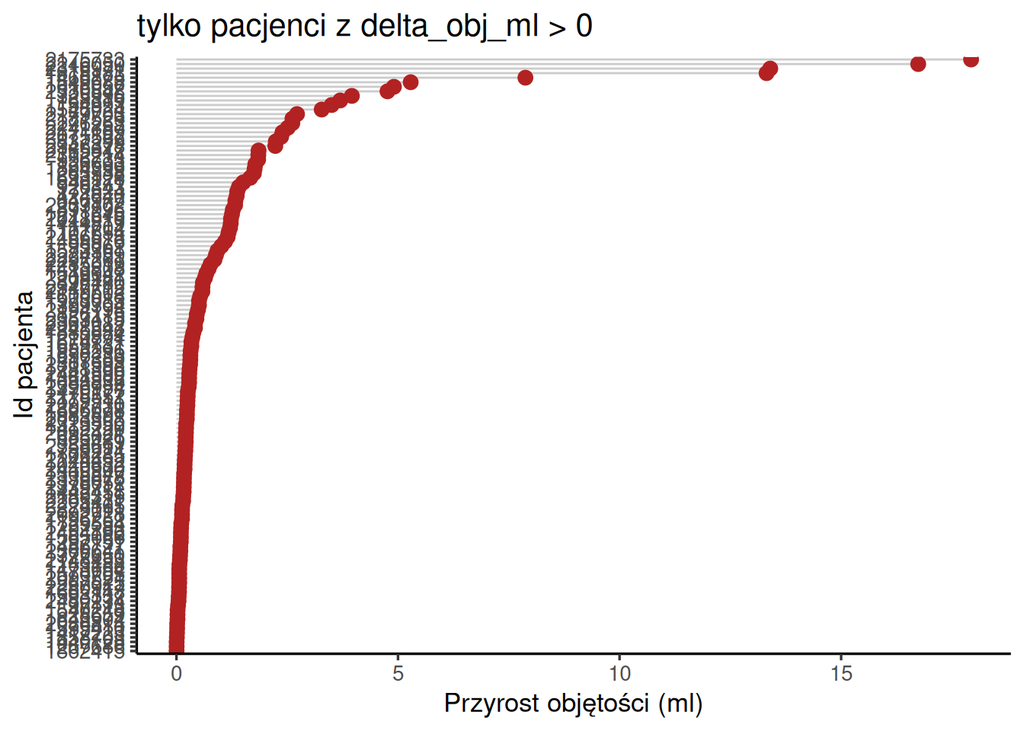

```r
wykr_zm_obj_wzrosty_dane <- wykr_zm_obj_wzrosty_dane %>%
  arrange(obj_delta_ml) %>%
  mutate(
    pacjent_id_fct = factor(pacjent_id, levels = pacjent_id)
  )

ggplot(wykr_zm_obj_wzrosty_dane, aes(x = obj_delta_ml, y = pacjent_id_fct)) +
  geom_segment(aes(xend = 0, yend = pacjent_id_fct),
               colour = "grey80") +
  geom_point(size = 3, colour = "firebrick") +
  labs(x = "Przyrost objętości (ml)",
       y = "Id pacjenta",
       title = "tylko pacjenci z delta_obj_ml > 0") +
  theme(panel.grid.major.y = element_blank())
```

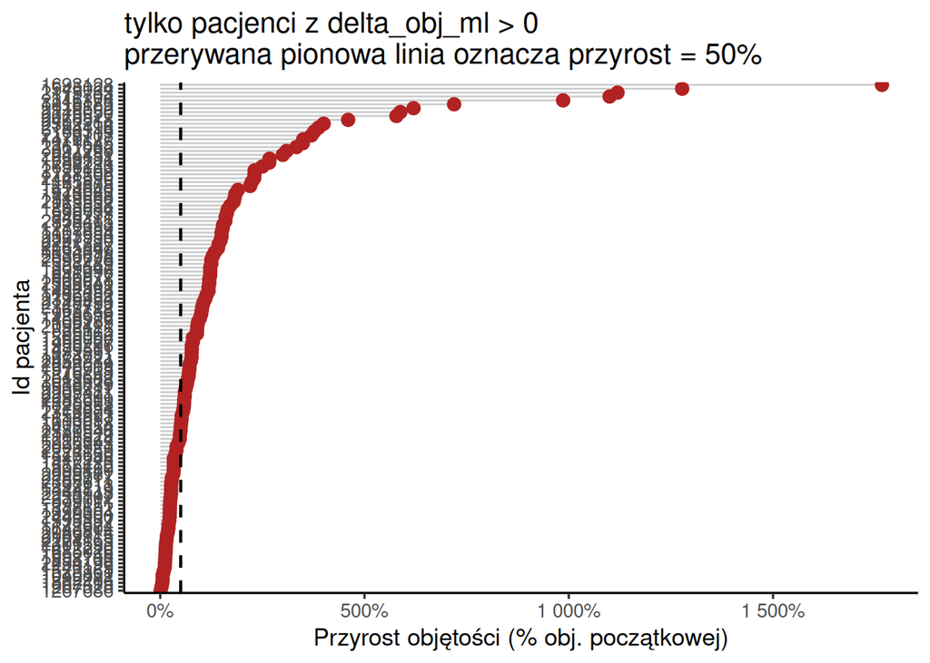

```r
wykr_zm_obj_wzrosty_dane <- wykr_zm_obj_wzrosty_dane %>%
  arrange(obj_delta_pct) %>%
  mutate(
    pacjent_id_fct = factor(pacjent_id, levels = pacjent_id)
  )

wykr_zm_obj_wzrosty_pct <- ggplot(wykr_zm_obj_wzrosty_dane, aes(x = obj_delta_pct, y = pacjent_id_fct)) +
  geom_segment(aes(xend = 0, yend = pacjent_id_fct),
               colour = "grey80") +
  geom_point(size = 3, colour = "firebrick") +
  geom_vline(xintercept = 50, linetype = "dashed", colour = "black", linewidth = 0.8) +
  scale_x_continuous(labels = label_percent(accuracy = 100, scale=1)) +
  labs(x = "Przyrost objętości (% obj. początkowej)",
       y = "Id pacjenta",
       title = "tylko pacjenci z delta_obj_ml > 0 \nprzerywana pionowa linia oznacza przyrost = 50%") +
  theme(panel.grid.major.y = element_blank())

wykr_zm_obj_wzrosty_pct
```

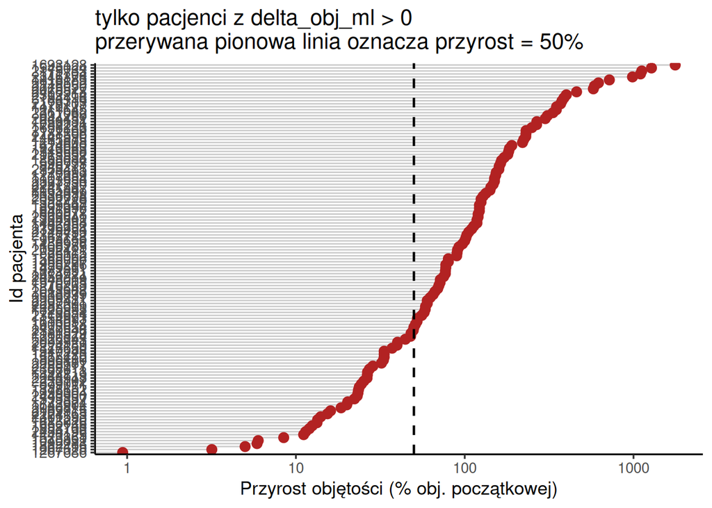

```r
 wykr_zm_obj_wzrosty_pct + scale_x_log10()
```

## Czy przyrost objętości zależy od wielkości guzka?

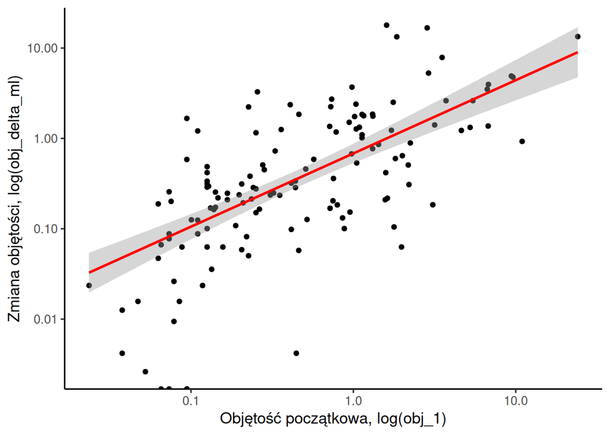

```r
ggplot(bethIV_2_lata, aes(x = obj_1, y = obj_delta_ml)) +
  geom_point() +
  scale_x_log10() +
  scale_y_log10() +
  geom_smooth(method = "lm", se = TRUE, color = "red") +
  labs(
    x = "Objętość początkowa, log(obj_1)",
    y = "Zmiana objętości, log(obj_delta_ml)"
  )
```

## Ile osób miało progresję wielkości wg kryterium przyrost obj. o >50% ?

```r
bethIV_2_lata %>%
  count(progresja_vol50)
```

```
## # A tibble: 2 × 2
##   progresja_vol50     n
##             <int> <int>
## 1               0    91
## 2               1    89
```

## Badanie ilosci kobiet i mężczyzn w grupie osób z progresją_vol50 i bez:

```r
bethIV_2_lata %>%
  group_by(progresja_vol50) %>%
  count(sex)
```

```
## # A tibble: 4 × 3
## # Groups:   progresja_vol50 [2]
##   progresja_vol50 sex       n
##             <int> <chr> <int>
## 1               0 K        83
## 2               0 M         8
## 3               1 K        74
## 4               1 M        15
```

## Badanie procentowej ilosci kobiet w grupie osób z progresją_vol50 i bez:

```r
bethIV_2_lata %>%
  group_by(progresja_vol50) %>%
  summarise(procent_kobiet = 100 * mean(sex == "K", na.rm = TRUE))
```

```
## # A tibble: 2 × 2
##   progresja_vol50 procent_kobiet
##             <int>          <dbl>
## 1               0           91.2
## 2               1           83.1
```

## Badanie istotności różnicy w proporcji kobiet/mężczyzn w grupie osób z progresją_vol50 i bez:

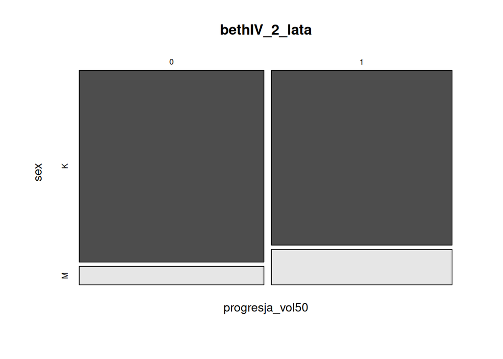

```r
mosaicplot(~ progresja_vol50 + sex, data = bethIV_2_lata, color = TRUE)
```

```r
pairwise_fisher_test(table(bethIV_2_lata$progresja_vol50, bethIV_2_lata$sex), p.adjust.method = "fdr")
```

```
## # A tibble: 1 × 6
##   group1 group2     n     p p.adj p.adj.signif
## * <chr>  <chr>  <int> <dbl> <dbl> <chr>
## 1 0      1        180 0.122 0.122 ns
```

## Badanie ilosci osób ze zmianą onkocytarną i nie w grupie osób z progresją_vol50 i bez:

```r
bethIV_2_lata %>%
  group_by(progresja_vol50) %>%
  count(onkocytarna)
```

```
## # A tibble: 4 × 3
## # Groups:   progresja_vol50 [2]
##   progresja_vol50 onkocytarna     n
##             <int>       <dbl> <int>
## 1               0           0    72
## 2               0           1    19
## 3               1           0    65
## 4               1           1    24
```

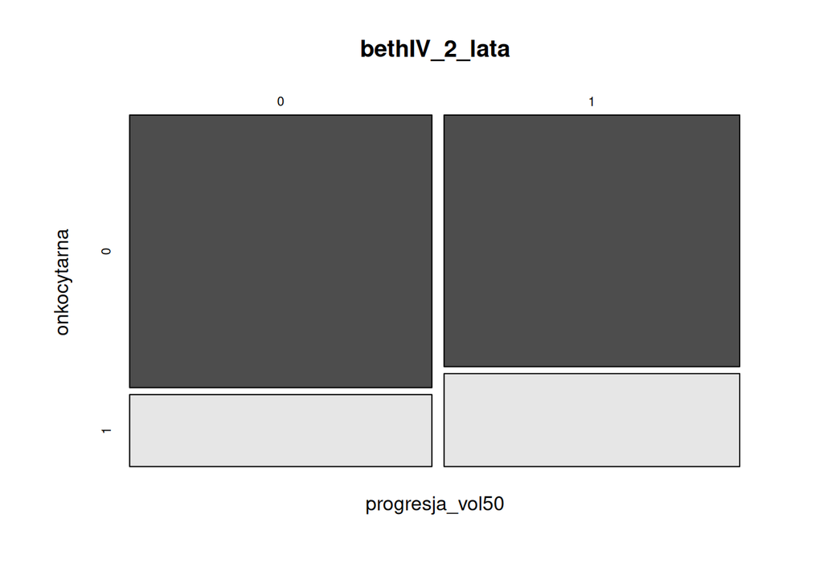

```r
mosaicplot(~ progresja_vol50 + onkocytarna, data = bethIV_2_lata, color = TRUE)
```

```r
pairwise_fisher_test(table(bethIV_2_lata$progresja_vol50, bethIV_2_lata$onkocytarna), p.adjust.method = "fdr")
```

```
## # A tibble: 1 × 6
##   group1 group2     n     p p.adj p.adj.signif
## * <chr>  <chr>  <int> <dbl> <dbl> <chr>
## 1 0      1        180 0.384 0.384 ns
```

## Badanie ilosci osób z AITD w grupie osób z progresją_vol50 i bez:

```r
bethIV_2_lata %>%
  group_by(progresja_vol50) %>%
  count(AITD)
```

```
## # A tibble: 4 × 3
## # Groups:   progresja_vol50 [2]
##   progresja_vol50  AITD     n
##             <int> <dbl> <int>
## 1               0     0    71
## 2               0     1    20
## 3               1     0    72
## 4               1     1    17
```

## Badanie różnicy wieku w grupie osób z progresją_vol50 i bez:

```r
bethIV_2_lata %>%
  group_by(progresja_vol50) %>%
  get_summary_stats(wiek)
```

```
## # A tibble: 2 × 14
##   progresja_vol50 variable     n   min   max median    q1    q3   iqr   mad
##             <int> <fct>    <dbl> <dbl> <dbl>  <dbl> <dbl> <dbl> <dbl> <dbl>
## 1               0 wiek        91  24.9  83.5   52.6  42.5  65.9  23.4  16.5
## 2               1 wiek        89  26.8  85.4   54.5  44.0  66.7  22.7  16.9
## # ℹ 4 more variables: mean <dbl>, sd <dbl>, se <dbl>, ci <dbl>
```

## Badanie istotności różnicy wieku w grupie osób z progresją_vol50 i bez:

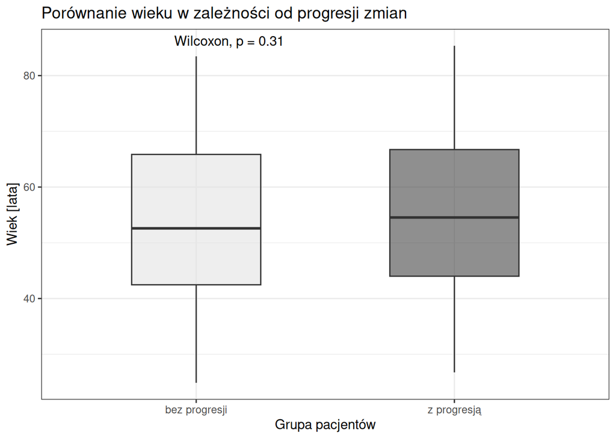

```r
# Przygotowanie danych: tylko TRUE/FALSE, bez NA i z etykietami "tak"/"nie"
beth_clean <- bethIV_2_lata %>%
  mutate(progresja_logiczna = progresja_vol50 == 1) %>%     # zamiana 1/0 na TRUE/FALSE
  filter(!is.na(progresja_logiczna)) %>%
  mutate(progresja_grupa = factor(
    if_else(progresja_logiczna, "z progresją", "bez progresji"),
    levels = c("bez progresji", "z progresją")
  ))

# Test statystyczny – Wilcoxon
wynik_testu <- wilcox.test(wiek ~ progresja_vol50, data = beth_clean)


# Wykres
ggplot(beth_clean, aes(x = progresja_grupa, y = wiek, fill = progresja_grupa)) +
  geom_boxplot(alpha = 0.6, width = 0.5) +
  labs(x = "Grupa pacjentów", y = "Wiek [lata]",
       title = "Porównanie wieku w zależności od progresji zmian") +
  stat_compare_means() +
  scale_fill_manual(values = c("gray89", "gray27")) +
  theme_bw() +
  theme(legend.position = "none")
```

## Badanie ilosci osób ze zmianą złośliwą w grupie osób z progresją_vol50 i bez:

```r
bethIV_2_lata_operowani <- bethIV_2_lata %>%
  filter(operowany == 1)

bethIV_2_lata_operowani %>%
  group_by(progresja_vol50) %>%
  count(zlosliwa)
```

```
## # A tibble: 4 × 3
## # Groups:   progresja_vol50 [2]
##   progresja_vol50 zlosliwa     n
##             <int>    <dbl> <int>
## 1               0        0    13
## 2               0        1     1
## 3               1        0    16
## 4               1        1     5
```

```r
bethIV_2_lata %>%
  group_by(progresja_vol50) %>%
  summarise(procent_zlosliwy = 100 * mean(zlosliwa == 1, na.rm = TRUE))
```

```
## # A tibble: 2 × 2
##   progresja_vol50 procent_zlosliwy
##             <int>            <dbl>
## 1               0             1.10
## 2               1             5.62
```

## Badanie istotności różnicy w proporcji zmian złośiwych i łagodnych w grupie osób z progresją_vol50 i bez:

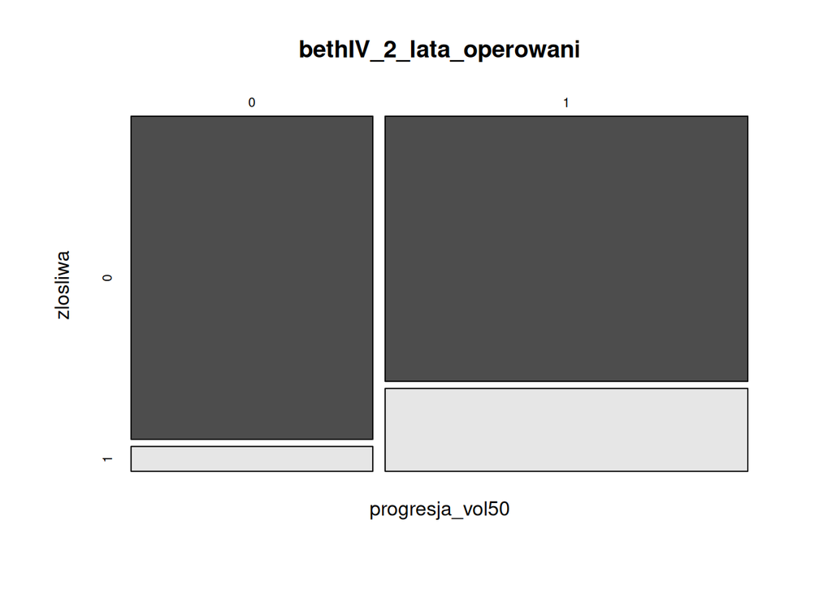

```r
mosaicplot(~ progresja_vol50 + zlosliwa, data = bethIV_2_lata_operowani, color = TRUE)
```

```r
pairwise_fisher_test(table(bethIV_2_lata_operowani$progresja_vol50, bethIV_2_lata_operowani$zlosliwa), p.adjust.method = "fdr")
```

```
## # A tibble: 1 × 6
##   group1 group2     n     p p.adj p.adj.signif
## * <chr>  <chr>  <int> <dbl> <dbl> <chr>
## 1 0      1         35 0.366 0.366 ns
```

## obj_log_fold_change – ocena dynamiki wzrostu guzków

zmienna określa ilukrotnie guzek powiększył swoją objętość w trakcie obserwacji. Punktem wyjścia jest $fold{\_}change=obj_2/obj_1$, ale wyrażone jest to na skali logarytmicznej, czyli ostatecznie $log{\_}fold{\_}change = log(obj_2/obj_1)$

wartość obj_log_fold_change = log(2) = 0.6931472 odpowiada 2x powiększeniu się

wartości logarytmów przykladowych wartości:

```r
tibble(
  x = c(1.5, 2,3,4,5,10),
  log_x = log(x)
)
```

```
## # A tibble: 6 × 2
##       x log_x
##   <dbl> <dbl>
## 1   1.5 0.405
## 2   2   0.693
## 3   3   1.10
## 4   4   1.39
## 5   5   1.61
## 6  10   2.30
```

nasze kryterium wzrostu o 50% odpowiada wartości obj_log_fold_change = log(1.5) = 0.4054651

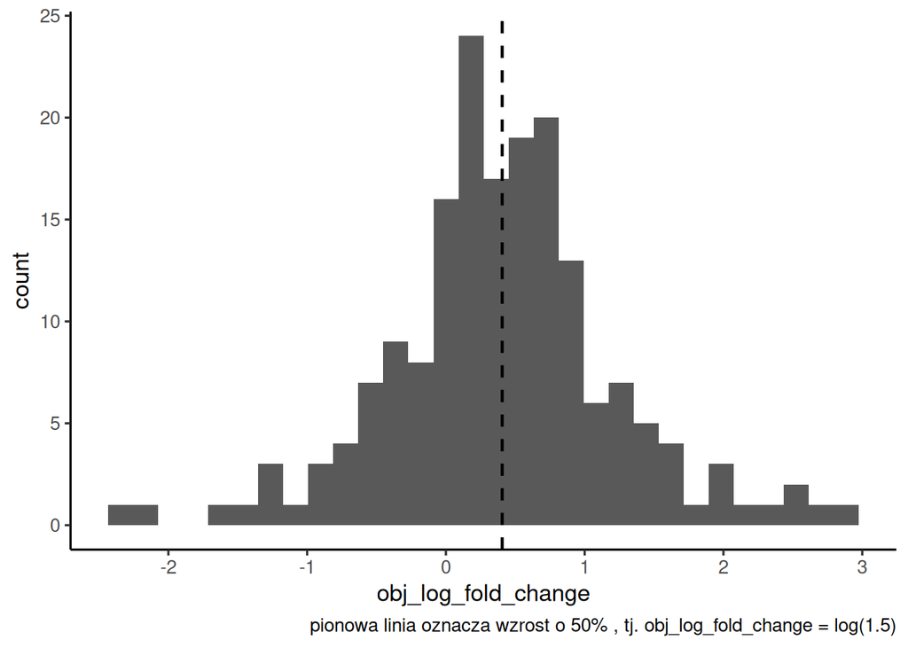

```r
ggplot(bethIV_2_lata, aes(obj_log_fold_change)) +
  geom_histogram() +
  geom_vline(xintercept = log(1.5), linetype = "dashed", colour = "black", linewidth = 0.8) +
  labs(
    caption = "pionowa linia oznacza wzrost o 50% , tj. obj_log_fold_change = log(1.5)"
  )
```

## obj_log_fold_change – ocena dynamiki wzrostu guzków wśród pacjentów z progresją

Wartości w skali log

```r
  quantile(bethIV_2_lata_progresja$obj_log_fold_change)
```

```
##        0%       25%       50%       75%      100%
## 0.4054651 0.5877867 0.8266786 1.1966735 2.9267394
```

Wartości w natywnej skali

```r
  exp(quantile(bethIV_2_lata_progresja$obj_log_fold_change))
```

```
##        0%       25%       50%       75%      100%
##  1.500000  1.800000  2.285714  3.309091 18.666667
```

# Wartości w skali procentowej

```r
  100*(exp(quantile(bethIV_2_lata_progresja$obj_log_fold_change))-1)
```

```
##        0%       25%       50%       75%      100%
##   50.0000   80.0000  128.5714  230.9091 1766.6667
```

## progresja_vol129 – podział pacj. z progresją na tych z względnie mniejszą i większą

```r
bethIV_2_lata_progresja %>%
  count(progresja_vol129)
```

```
## # A tibble: 2 × 2
##   progresja_vol129     n
##              <int> <int>
## 1                0    45
## 2                1    44
```

## Badanie ilosci osób ze zmianą złośliwą w grupie osób z progresja_vol129 i bez:

```r
  bethIV_2_lata_operowani %>%
  group_by(progresja_vol129) %>%
  count(zlosliwa)
```

```
## # A tibble: 4 × 3
## # Groups:   progresja_vol129 [2]
##   progresja_vol129 zlosliwa     n
##              <int>    <dbl> <int>
## 1                0        0    16
## 2                0        1     3
## 3                1        0    13
## 4                1        1     3
```

## Badanie istotności różnicy w proporcji zmian złośiwych i łagodnych w grupie osób z progresją_vol129 i bez:

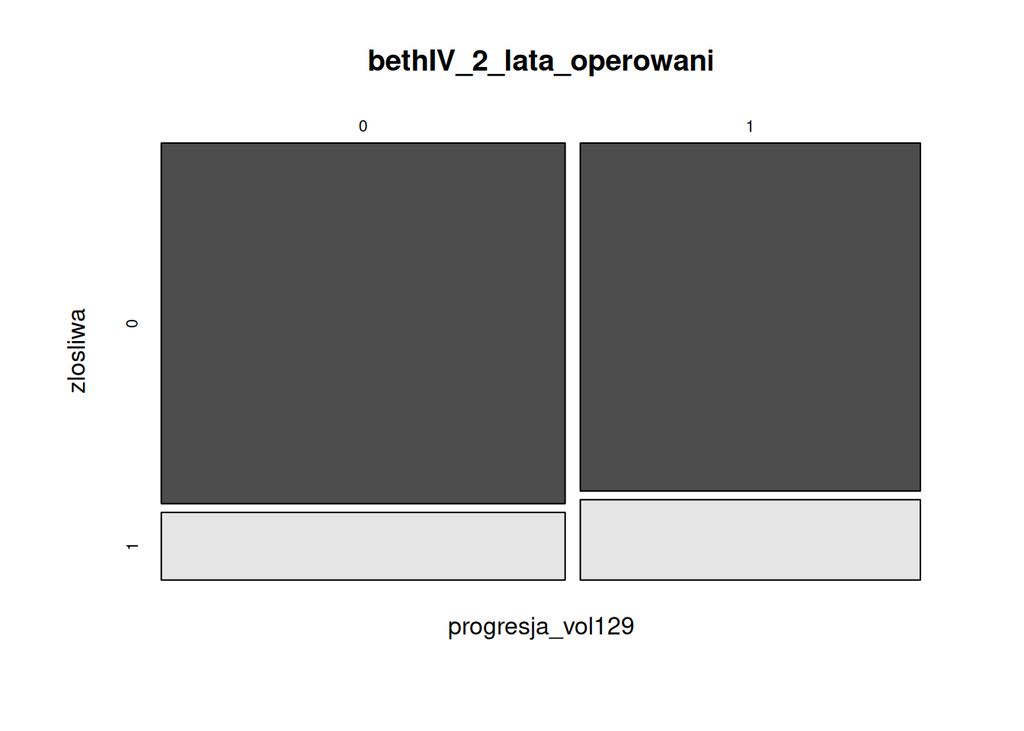

```r
mosaicplot(~ progresja_vol129 + zlosliwa, data = bethIV_2_lata_operowani, color = TRUE)
```

```r
pairwise_fisher_test(table(bethIV_2_lata_operowani$progresja_vol129, bethIV_2_lata_operowani$zlosliwa), p.adjust.method = "fdr")
```

```
## # A tibble: 1 × 6
##   group1 group2     n     p p.adj p.adj.signif
## * <chr>  <chr>  <int> <dbl> <dbl> <chr>
## 1 0      1         35     1     1 ns
```